# E3

2023-02-01

## Frage 1: Wie viele eindeutige Nutzer suchten nach der E3?

SELECT count(distinct anonid) FROM aol_data where query like ‘e3’ or query like ‘e3 %’ or query like ‘% e3’ or query like ‘% e3 %’ ;

Dieser Befehl ergibt: 222.

SELECT count(distinct anonid) FROM aol_data where clickurl like ‘%e3expo.com%’ or clickurl like ‘%e3insider.com%’ ;

Dieser Befehl ergibt: 139.

Eine Vergleich der jeweils nur in einem Ergebnis enthaltenen Queries ergab, dass auch nach `e3.com` gesucht werden sollte. Sonst findet man 28 valide Treffer im ersten Befehl nicht! In der Vereinigung erhät man 265 eindeutige Nutzer (inklusive false positives).

Sucht man nach allen Suchbegriffen, die Nutzer auf die Seiten der e3 landeten, erhält man 348 Personen. Hierunter sind aber auch Suchenanfragen, die vermutlich gar nicht auf die e3 abzielten. So oder so: man muss per Hand die Ergebnisse selektieren.

False positive rate des ersten Befehls ca. 10 %. Hier ein prominenter missmatch:

[figure not shown]

## Frage 2: Wie sieht die zeitliche Verteilung der Suchanfragen aus Frage 1 aus?

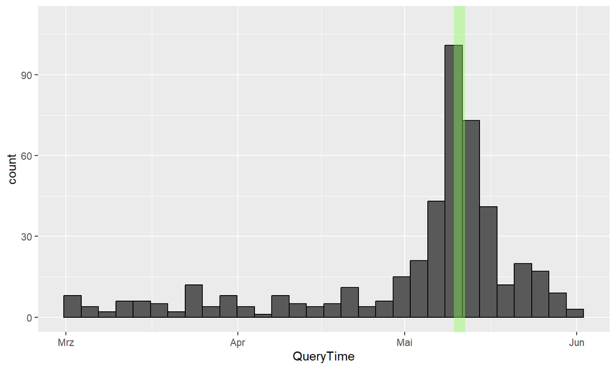

## Probleme

- Verbindung zur Datenbank aus R heraus (Windows ODBC konnte nicht erstellt werden)
- Kreuzprodukte für `LIKE` Anfragen schnell zu groß
  - besser eine Funktion nutzen, die einen SQL-Befehl mit ganz vielen `OR` erstellt
  - oder einzelne queries schicken und die Daten extern sammeln, damit man auch noch den Text der einen Query als neue Spalte anfügen kann
- Oracle beschwert sich, wenn nicht alle selektierten Attribute gruppiert oder aggregiert werden
  - `GROUP BY` vs. `DISTINCT
- automatisierte Abfragen geben oft nur einen Ansatzpunkt dafür, die Abfragen händisch zu optimieren
  - Mit `%` muss man bei Abkürzungen sehr aufpassen. Leerzeichen können schon helfen. Aber `% ac %` findet man auch eine Menge, dass nicht mit Assassin’s Creed zu tun hat.
  - manchmal helfen aber auch eher die Abkürzungen (v. a. für etablierte Titel); bspw. `ps3`
- Das Nutzen von einer view, in der aggregiert wird, kann große Performanceeinbußen bringen; eine materialisierte view kann hier helfen (1000x gleiche Aggregation gemacht, weil die Operation hinter der view nicht mehr klar war)